# STAT 484 Homework 2

Jennifer Mullen

January 12, 2017

## Question 1

**try rep(4,times=5) and rep(c(1,2),each=3)**

```r
rep(4,times=5)
```

```
## [1] 4 4 4 4 4
```

```r
rep(c(1,2),each=3)
```

```
## [1] 1 1 1 2 2 2
```

**Use rep() to enter the sequence 1 1 1 1 2 2 2 2 3 3 3 3 repeated 3 times**

```r
(s <- rep(rep(1:3, each=3), each=3))
```

```
##  [1] 1 1 1 1 1 1 1 1 1 2 2 2 2 2 2 2 2 2 3 3 3 3 3 3 3 3 3
```

**Now convert it to a factor with the levels “Low”,“Medium”, and “High”**

```r
f <- factor(s)
levels(f) <- c("Low","Medium", "High")
f
```

```
##  [1] Low    Low    Low    Low    Low    Low    Low    Low    Low    Medium
## [11] Medium Medium Medium Medium Medium Medium Medium Medium High   High
## [21] High   High   High   High   High   High   High
## Levels: Low Medium High
```

**Can you change the levels to “Never”,“Rarely”,“Sometimes”?**

```r
levels(f) <- c("Never","Rarely","Sometimes")
f
```

```
##  [1] Never     Never     Never     Never     Never     Never     Never
##  [8] Never     Never     Rarely    Rarely    Rarely    Rarely    Rarely
## [15] Rarely    Rarely    Rarely    Rarely    Sometimes Sometimes Sometimes
## [22] Sometimes Sometimes Sometimes Sometimes Sometimes Sometimes
## Levels: Never Rarely Sometimes
```

## Question 2

**Convert the factor from Problem 1 into a character vector, and save it (assign it a name).**

```r
(f.chars <- as.factor(as.character(f)))
```

```
##  [1] Never     Never     Never     Never     Never     Never     Never
##  [8] Never     Never     Rarely    Rarely    Rarely    Rarely    Rarely
## [15] Rarely    Rarely    Rarely    Rarely    Sometimes Sometimes Sometimes
## [22] Sometimes Sometimes Sometimes Sometimes Sometimes Sometimes
## Levels: Never Rarely Sometimes
```

**Can you convert the character vector to a numeric vector?**

```r
as.numeric(f.chars)
```

```
##  [1] 1 1 1 1 1 1 1 1 1 2 2 2 2 2 2 2 2 2 3 3 3 3 3 3 3 3 3
```

## Question 3

```r
(a <-factor(scan(text="2 4 3 3 2 1 1 2 3 4 2 3 3 4 1 3 2 1 4 3 2 4")))
```

```
##  [1] 2 4 3 3 2 1 1 2 3 4 2 3 3 4 1 3 2 1 4 3 2 4
## Levels: 1 2 3 4
```

**Convert a into an ordered factor with levels “Sm”,“Med”,“Lg”,“X-Lg” (with 1 for “Sm”)**

```r
(levels(a) <- c("Sm", "Med", "Lg", "X-Lg"))
```

```
## [1] "Sm"   "Med"  "Lg"   "X-Lg"
```

```r
(a <- ordered(a))
```

```
##  [1] Med  X-Lg Lg   Lg   Med  Sm   Sm   Med  Lg   X-Lg Med  Lg   Lg   X-Lg
## [15] Sm   Lg   Med  Sm   X-Lg Lg   Med  X-Lg
## Levels: Sm < Med < Lg < X-Lg
```

**How many values are equal to or larger than “Lg”?**

```r
(length(a[a >= "Lg"]))
```

```
## [1] 12
```

## Question 4

*I realized that this question can be interpreted two different ways. The first is to count the number of times # a value appears per die. In other words, if the result of a roll is (1, 1) then the frequency of rolling a 1 is 2. I don’t think this is the correct interpretation, but just in case I’m including it here.*

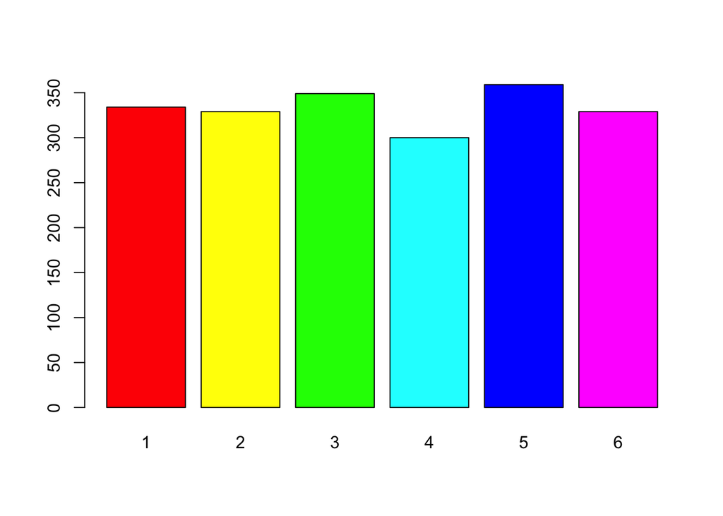

```r
roll.die1 <- sample(x=1:6, size=1000, replace=TRUE)
roll.die2 <- sample(x=1:6, size=1000, replace=TRUE)
roll.all <- c(roll.die1, roll.die2)
barplot(table(roll.all), col=rainbow(6))
```

*The second interpretation, which I believe is the one intended, is to count the frequence of a number appearing per roll of both dice. In this case, rolling (1, 1) would give 1 a frequence of 1, not 2. We can remove the duplicates by combinging both vectors into one, but adding the value of the second only if it does not match the value in the first vector.*

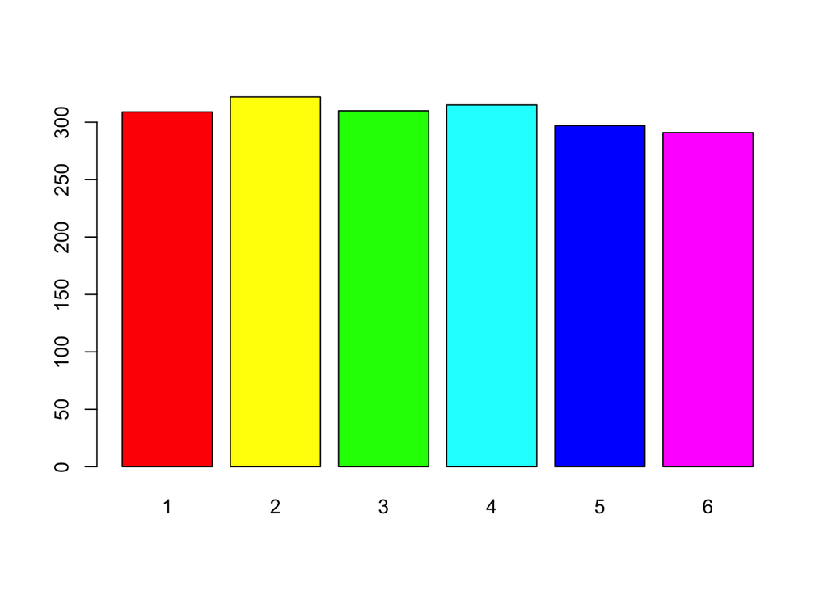

```r
roll.die1 <- sample(x=1:6, size=1000, replace=TRUE)
roll.die2 <- sample(x=1:6, size=1000, replace=TRUE)
roll.unique = c(roll.die1, roll.die2[roll.die2 != roll.die1])
barplot(table(roll.unique), col=rainbow(6))
```

**Extra: What happens if the two dice have different numbers of sides?** *The frequency for shared sides will tend to be higher than non-shared.*

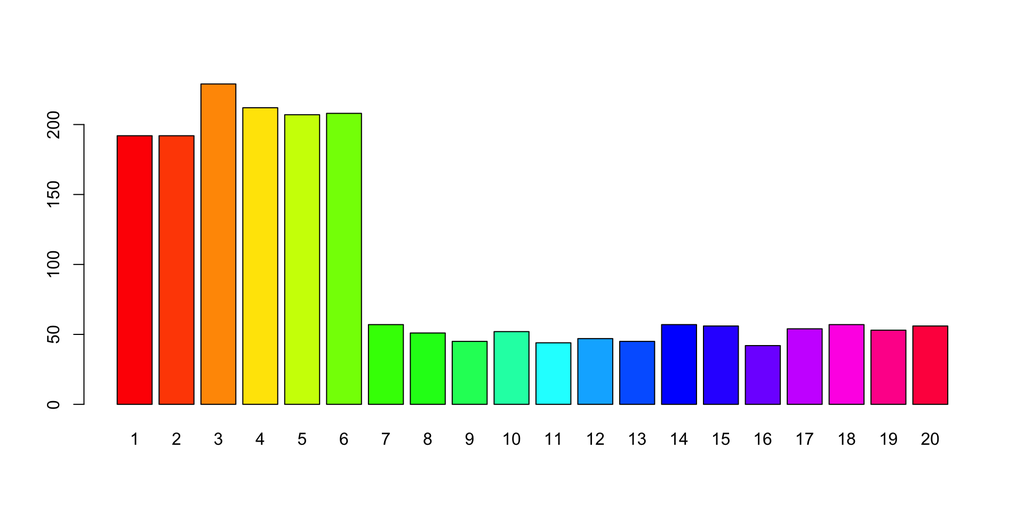

```r
d6 <- sample(x=1:6, size=1000, replace=TRUE)
d20 <- sample(x=1:20, size=1000, replace=TRUE)
rolls <- c(d6, d20[d20 != d6])
barplot(table(rolls), col=rainbow(20), width=0.75)
```